# bagg

Liang

07/01/2022

```r
library(stringr)
library(rpart)
library(pROC)
library(h2o)
```

```r
library(rpart.plot)
library(caret)
setwd("~/../LX_Project/cart/tutorial2//")
source("helperfunctions.R")
```

### Introduction

Previously we explored two basic tree-based models: classification and regression trees. The performance of a single regression or classification tree is limited. Ensemble methods combine a number of simpler models and are more powerful than individual decision trees. This tutorial will help the readers familiarize with popular ensemble techniques including bootstrap aggregating (bagging), random forest and boosting. The right heart catheterization (RHC) and diabetes readmission datasets will be used to construct examples.

#### Bootstrap Aggregating

Predictions from individual decision trees tend to have high variance. Different subsamples could lead to different tree structures and, as a result, unstable predictions. Bootstrap aggregating (bagging) reduces variance by aggregating the predictions of trees built from bootstrap samples. A bootstrap sample is generated by sampling with replacement from the original dataset. For regression trees, the average of predictions is taken as the aggregated prediction. For classification trees, the aggregated prediction corresponds to the category with the highest frequency of appearance (majority vote) amongst the predictions.

Bagging also provides an internal assessment of the model’s predictive ability. For a bootstrap sample, some observations are left out (out-of-bag). Since the out-of-bag observations are not involved in generating the predictions for the bootstrap sample, they can be used to compute the out-of-bag error as a measure of the bagging model’s predictive performance.

##### Bagging for continuous response with the RHC data

The Right Heart Catherization (RHC) dataset is prepared following the steps outlined in “R Guide for TMLE in Medical Research” (https://ehsanx.github.io/TMLEworkshop/).

```r
rhcdata <- read.csv("rhc.csv") # load data

# add column for outcome Y: length of stay
# Y = date of discharge - study admission date
# Y = date of death - study admission date if date of discharge not available
rhcdata$Y <- rhcdata$dschdte - rhcdata$sadmdte
rhcdata$Y[is.na(rhcdata$Y)] <- rhcdata$dthdte[is.na(rhcdata$Y)] -
  rhcdata$sadmdte[is.na(rhcdata$Y)]
# remove outcomes we are not examining in this example
rhcdata <- dplyr::select(rhcdata,
                         !c(dthdte, lstctdte, dschdte, death, t3d30, dth30, surv2md1))
# remove unnecessary and problematic variables
rhcdata <- dplyr::select(rhcdata,
                         !c(sadmdte, ptid, X, adld3p, urin1, cat2))

# convert all categorical variables to factors
factors <- c("cat1", "ca", "cardiohx", "chfhx", "dementhx", "psychhx",
             "chrpulhx", "renalhx", "liverhx", "gibledhx", "malighx",
             "immunhx", "transhx", "amihx", "sex", "dnr1", "ninsclas",
             "resp", "card", "neuro", "gastr", "renal", "meta", "hema",
             "seps", "trauma", "ortho", "race", "income")
rhcdata[factors] <- lapply(rhcdata[factors], as.factor)
# convert our treatment A (RHC vs. No RHC) to a binary variable
rhcdata$A <- ifelse(rhcdata$swang1 == "RHC", 1, 0)
rhcdata <- dplyr::select(rhcdata, !swang1)
# Categorize the variables to match with the original paper
rhcdata$age <- cut(rhcdata$age,breaks=c(-Inf, 50, 60, 70, 80, Inf),right=FALSE)
rhcdata$race <- factor(rhcdata$race, levels=c("white","black","other"))
rhcdata$sex <- as.factor(rhcdata$sex)
rhcdata$sex <- relevel(rhcdata$sex, ref = "Male")
rhcdata$cat1 <- as.factor(rhcdata$cat1)
levels(rhcdata$cat1) <- c("ARF","CHF","Other","Other","Other",
                          "Other","Other","MOSF","MOSF")
rhcdata$ca <- as.factor(rhcdata$ca)
levels(rhcdata$ca) <- c("Metastatic","None","Localized (Yes)")
rhcdata$ca <- factor(rhcdata$ca, levels=c("None",
                                          "Localized (Yes)","Metastatic"))

# Rename variables
names(rhcdata) <- c("Disease.category", "Cancer", "Cardiovascular",
                    "Congestive.HF", "Dementia", "Psychiatric", "Pulmonary",
                    "Renal", "Hepatic", "GI.Bleed", "Tumor",
                    "Immunosupperssion", "Transfer.hx", "MI", "age", "sex",
                    "edu", "DASIndex", "APACHE.score", "Glasgow.Coma.Score",
                    "blood.pressure", "WBC", "Heart.rate", "Respiratory.rate",
                    "Temperature", "PaO2vs.FIO2", "Albumin", "Hematocrit",
                    "Bilirubin", "Creatinine", "Sodium", "Potassium", "PaCo2",
                    "PH", "Weight", "DNR.status", "Insurance",
                    "Respiratory.Diag", "Cardiovascular.Diag",
                    "Neurological.Diag", "Gastrointestinal.Diag", "Renal.Diag",
                    "Metabolic.Diag", "Hematologic.Diag", "Sepsis.Diag",
                    "Trauma.Diag", "Orthopedic.Diag", "race", "income",
                    "Y", "A")

levels(rhcdata$Insurance) = c("Medicaid", "Medicare", "M&M", "None", "Priv", "Priv&Medicare")
```

##### Step by step breakdown

1. Set $K$ as the number of bootstrap samples and $N$ as the total number of observations. In the case of the RHC data, $N = 5735$. Let $K = 3$ for the demonstration purposes.

```r
nrow(rhcdata)
```

```
## [1] 5735
```

2. For each bootstrap sample $i$ from $1$ to $K$, sample $N$ observations randomly with replacement to generate the $i$<sup>th</sup> bootstrap sample.

```r
set.seed(123)
data_list = index = list() # empty list to store bootstrap samples
for(i in 1:3){
  index[[i]] = sample(nrow(rhcdata),  replace = TRUE)
  data_list[[i]] = rhcdata[index[[i]], ]
}
```

3. For each bootstrap sample $i$ from $1$ to $K$, build a regression tree. We will use package ‘rpart’ to generate the trees. Let the minimum node side be 2000

```r
tree_list = list() # empty list to store trees
for(i in 1:3){
  tree_list[[i]] = rpart(formula = Y ~ ., minsplit = 2000, data = data_list[[i]], cp=-1)
}
```

The three trees were built using random bootstrap samples that differed from each other. The resulting trees are also slightly different as a consequence. The output for the three trees are as follows:

```r
tree_list
```

```
## [[1]]
## n= 5735
##
## node), split, n, deviance, yval
##       * denotes terminal node
##
##  1) root 5735 3426351 21.07358
##    2) Disease.category=CHF,Other 1597  509740 15.44271 *
##    3) Disease.category=ARF,MOSF 4138 2846433 23.24674
##      6) A< 0.5 2368 1318326 21.08404
##       12) Bilirubin< 0.9499512 810  236064 17.60247 *
##       13) Bilirubin>=0.9499512 1558 1067340 22.89409 *
##      7) A>=0.5 1770 1502213 26.14011 *
##
## [[2]]
## n= 5735
##
## node), split, n, deviance, yval
##       * denotes terminal node
##
##  1) root 5735 3950939.0 21.45371
##    2) Disease.category=CHF,Other 1603  465573.7 14.85590 *
##    3) Disease.category=ARF,MOSF 4132 3388514.0 24.01331
##      6) Albumin>=2.249756 3351 2128286.0 22.39988
##       12) age=[70,80),[80, Inf) 1203  465893.6 19.04489 *
##       13) age=[-Inf,50),[50,60),[60,70) 2148 1641268.0 24.27886
##         26) A< 0.5 1281  779241.2 22.18501 *
##         27) A>=0.5 867  848112.7 27.37255 *
##      7) Albumin< 2.249756 781 1214077.0 30.93598 *
##
## [[3]]
## n= 5735
##
## node), split, n, deviance, yval
##       * denotes terminal node
##
##  1) root 5735 3670304.0 21.30410
##    2) Disease.category=CHF,Other 1661  601050.4 15.57315 *
##    3) Disease.category=ARF,MOSF 4074 2992458.0 23.64065
##      6) Cancer=Localized (Yes),Metastatic 1090  387565.3 19.09908 *
##      7) Cancer=None 2984 2574198.0 25.29960
##       14) Hematocrit>=32.04688 1035  561678.7 19.90531 *
##       15) Hematocrit< 32.04688 1949 1966409.0 28.16419 *
```

The trees can be visualized using the package ‘rpart.plot’:

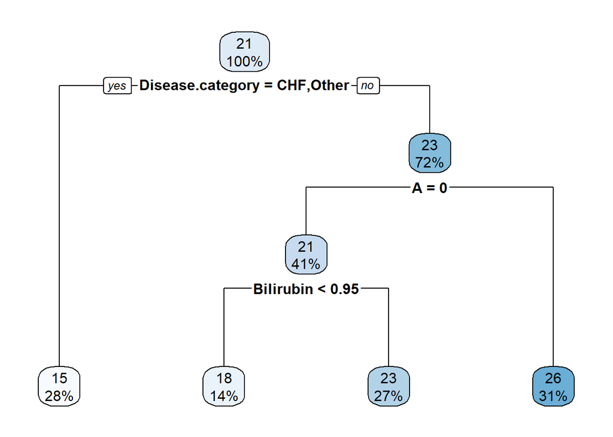

```r
rpart.plot(tree_list[[1]])
```

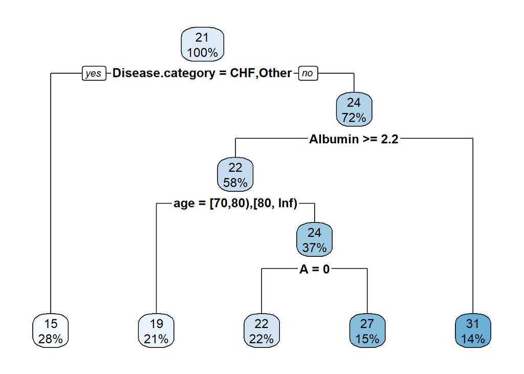

```r
rpart.plot(tree_list[[2]])
```

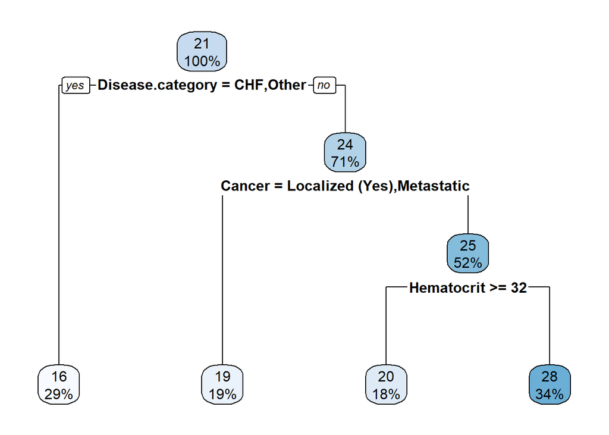

```r
rpart.plot(tree_list[[3]])
```

4. For each observation in the original dataset $j$ from $1$ to $N$, generate a prediction using the set of bootstrap models that did not include it. Different bootstrap models can generate different predictions for the same observation. Such predictions can be combined to yield a single estimate. For continuous response, the estimate can be the average of the predictions. For binary response, the estimate can be the majority vote, which corresponds to the category with the highest frequency of appearance.

```r
pred = c() # vector of predictions

# for the ith observation:
for(i in 1:nrow(rhcdata)){
  # the ith prediction is calculated from trees that did not use the ith observation :
  pred_i = sapply(1:length(index), function(j){
    # only produce a prediction from the jth model if it didn't use the ith observation
    if((i %in% index[[j]]) == FALSE) predict(tree_list[[j]], newdata = rhcdata[i,]) else NA
       })
  # record the mean of predictions
  pred[i] = mean(pred_i, na.rm = TRUE)
}
```

5. Compute the out-of-bag error

The out-of-bag error for continuous response is given by the root of the mean squared difference between the predictions and the observed values:

```r
sqrt(mean((pred - rhcdata$Y)^2, na.rm = TRUE))
```

```
## [1] 25.52322
```

Note that there are several ‘NA’ values in ‘pred’ due to the small number of bootstrap samples.

```r
head(pred)
```

```
## [1]      NaN      NaN 26.75633 17.60247      NaN 15.50793
```

These entries correspond to entries that pertain to all three bootstrap samples, so that out-of-bag predictions could not be generated. Working with more bootstrap samples will drastically reduce such occurences.

Let’s repeat the above steps with a larger boostrap sample (e.g. N=100).

```r
N=100

# setting up bootstrap samples
set.seed(123)
data_list = index = list() # empty list to store bootstrap samples
for(i in 1:N){
  index[[i]] = sample(nrow(rhcdata),  replace = TRUE)
  data_list[[i]] = rhcdata[index[[i]], ]
}

# constructing trees
tree_list = list() # empty list to store trees
for(i in 1:N){
  tree_list[[i]] = rpart(formula = Y ~ ., minsplit = 2000, data = data_list[[i]], cp=-1)
}

# generating predictions
# due to the size of 'rhcdata' (6k rows), this last part will take ~ 30 mins to run
pred = c()
for(i in 1:nrow(rhcdata)){
  # the ith prediction is calculated from trees that did not use the ith observation :
  pred_i = sapply(1:length(index), function(j){
    # only produce a prediction from the jth model if it didn't use the ith observation
    if((i %in% index[[j]]) == FALSE) predict(tree_list[[j]], newdata = rhcdata[i,]) else NA
       })
  # record the mean of predictions
  pred[i] = mean(pred_i, na.rm = TRUE)
}
sqrt(mean((pred - rhcdata$Y)^2, na.rm = TRUE))
```

```
## [1] 25.3901
```

Compare the results above against outputs from an existing R package ‘ipred’. The out-of-bag error given by ‘bagging’ should be similar to the out-of-bad error above. Note that at least 10 bootstrap samples are required.

```r
library(ipred)
bagging(
  formula = Y ~ .,
  data = rhcdata,
  nbagg = 100,
  coob = TRUE,
  control = rpart.control(minsplit = 2000, cp = -1)
)$err
```

```
## [1] 25.37382
```

##### Bagging for binary response

Bagging with a binary response follows a similar set of steps as with a continuous response. We will use the ‘kyphosis’ dataset from the package ‘rpart’ to illustrate the process.

```r
N=100

# setting up bootstrap samples
set.seed(123)
data_list = index = list() # empty list to store bootstrap samples
for(i in 1:N){
  index[[i]] = sample(nrow(rpart::kyphosis),  replace = TRUE)
  data_list[[i]] = rpart::kyphosis[index[[i]], ]
}

# constructing trees
tree_list = list() # empty list to store trees
for(i in 1:N){
  tree_list[[i]] = rpart(formula = Kyphosis ~ ., minsplit = 30, data = data_list[[i]], cp=-1)
}
```

The above steps are the same as with a continuous response. However, the way predictions are generated with a binary response is slightly different. Recall that with a continuous response, the predictions from various trees are averaged to produce the final prediction. For binary response, the predictions are also aggregated to produce the final prediction, but instead of taking the average, we take the ‘majority vote’. That is, the category earning the highest votes across all trees will win.

```r
# generating predictions
pred = c()
for(i in 1:nrow(kyphosis)){
  # the ith prediction is calculated from trees that did not use the ith observation :
  pred_i = sapply(1:length(index), function(j){
    # only produce a prediction from the jth model if it didn't use the ith observation
    if((i %in% index[[j]]) == FALSE) ifelse(predict(tree_list[[j]], type="class", newdata = rpart::kyphosis[i,])=="absent", 0, 1) else NA
       })
  # record the majority vote
  if(length(which(pred_i==0)) == length(which(pred_i==1))){
    # if the votes are even, pick randomly with equal probabilities:
    pred[i] = c("absent", "present")[sample(c(1,2), size = 1, prob = c(0.5, 0.5))]
        } else {
          # otherwise pick the majority vote:
          pred[i] = c("absent", "present")[which.max(c(length(which(pred_i==0)), length(which(pred_i==1))))]
        }
}
pred = as.factor(pred)
```

To estimate the accuracy of the predictions from bagging with a binary response, we can calculate the rate of missclassification:

```r
mean(kyphosis$Kyphosis != pred)
```

```
## [1] 0.2098765
```

We can again compare the above results to the ouputs from ‘bagging’ with package ‘ipred’:

```r
library(ipred)
bagging(
  formula = Kyphosis ~ .,
  data = kyphosis,
  nbagg = 100,
  coob = TRUE,
  control = rpart.control(minsplit = 30, cp = -1)
)$err
```

```
## [1] 0.2098765
```

#### Random Forest

In bagging, bootstrap samples are generated to build trees that vary in structure for better predictive performance. Despite the randomness introduced by bootstrapping, the resulting trees and their predictions are correlated, as the same set of predictors are used to build all trees. Random forest reduces correlation of the trees by selecting a random subset of predictors for each split within each tree. This introduces additional randomness that further reduces variance in the predictions. A good starting point for the number of randomly chosen predictors at each split is $\sqrt{p}$, where $p$ is the total number of predictors. Similar to bagging, random forest combines all the trees to generate an aggregated prediction.

The following codes for regression tree show one way to implement random forest.

```r
regtree <- function(data, resp, min.obs, feat = NULL, nfeat = NULL){
  # min.obs sets the minimum size for parent nodes
  # feat is the set of predictors

  if(is.null(feat)) feat = names(data)[names(data)!=resp] # if undefined, set feat to all covariates in the data
  leafsize = min.obs/3 # set minimum size for leaves or terminal nodes

  data.list = split_val = feat_list = list(); error = c() # empty objects
  data.list[[1]] = data # set root of tree

  # id of observations pertaning to each node
  node.ID = list(100)

  # data.frame to store output:
  output = data.frame(status = "split", count = nrow(data), "split rule" = "root", depth = 0, mean = mean(data[, resp]), stringsAsFactors = FALSE)

  stopsplit = FALSE; iter = 1 # initialization for while loop
  while(!stopsplit) {
    # list of splits to be done:
      split.queue = which(output$status == "split")

    for (j in split.queue[1]) {
      # load data corresponding to current node
      data.temp = data.list[[j]]

      ### additional condition for random forest
      if(!is.null(nfeat)) subfeat = sample(feat, nfeat, replace = FALSE) else subfeat = feat
        # For each feature of interest, determine the optimal split
      for (i in 1:length(subfeat)){

        data_sub = data.frame(var = data.temp[, subfeat[i]], resp = data.temp[, resp])

        # calculating sse for categorical feature:
        if(is.factor(data_sub$var)) {

          if( length(levels(data_sub$var)) > 2 ){
            # if more than 2 levels find all possible binary splits
            kk = 1
            varcomb = list()
            for (ii in 1:(length(levels(data_sub$var))-1)) {
              comb = combn(length(levels(data_sub$var)), ii)
              for (jj in 1:ncol(comb)){
                varcomb[[kk]] = levels(data_sub$var)[comb[, jj]]
                kk = kk +1
              }
            }

            # calculate sse for all possible splits
            sse = sapply(varcomb, function(varcomb_i){
              sum((data_sub$resp[data_sub$var %in% varcomb_i] - mean(data_sub$resp[data_sub$var %in% varcomb_i]))^2) + sum((data_sub$resp[!(data_sub$var %in% varcomb_i)] - mean(data_sub$resp[!(data_sub$var %in% varcomb_i)]))^2) })

            # checking size of children nodes; if less than specified by 'leafsize', the split is not considered
            count_min = sapply(varcomb, function(varcomb_i){min(length(data_sub$resp[data_sub$var %in% varcomb_i]), length(data_sub$resp[!(data_sub$var %in% varcomb_i)]))})
            for(ii in 1:length(varcomb)) {if(count_min[ii] < round(leafsize)) sse[ii] = NA}

            # clean up:
            if(all(is.na(sse))) {error[i] = NA; split_val[[i]] = NA} else { error[i] = min(sse, na.rm = TRUE); split_val[[i]] = varcomb[[which.min(sse)]]}

          } else {
            # if only two levels
            data.split = split(data_sub, data_sub$var)
            error[i] = sum(sapply(data.split, function(x){
              sum( (x$resp - mean(x$resp)) ^ 2 )
            }))

              # checking size of children nodes; if less than specified by 'leafsize', the split is not considered
              count_min = min(sapply(data.split, nrow))
              if( count_min < leafsize) error[i] = NA
          }

          # calculating sse for continuous feature:
        } else {
          splits_sort = sort(unique(data_sub$var)) # all possible splits
          sse <- c()

          # calculating sse for all possible splits
          for( k in 1:length(splits_sort)){
            sse[k] = sum( (data_sub$resp[data_sub$var < splits_sort[k]] - mean(data_sub$resp[data_sub$var < splits_sort[k]]) )^2 ) + sum( (data_sub$resp[data_sub$var >= splits_sort[k]] - mean(data_sub$resp[data_sub$var >= splits_sort[k]]) )^2 )

            # checking size of children nodes; if less than specified, the split is not considered
            count_min = min(length(data_sub$resp[data_sub$var < splits_sort[k]]), length(data_sub$resp[data_sub$var >= splits_sort[k]]))
            if(count_min < round(leafsize)) sse[k] = NA
          }
          # clean up for when none of the splits is valid:
          if(all(is.na(sse))) {error[i] = NA; split_val[[i]] = NA} else { error[i] = min(sse, na.rm = TRUE); split_val[[i]] = splits_sort[which.min(sse)]}
        }
      }

      if(all(is.na(error))){
        # if none of the splits is good, set the current node to 'leaf'
        output$status[j] = "leaf"
      } else {
        # otherwise proceed with the split and choose the feature leading to the lowest sse
        splitvar = subfeat[which.min(error)]

        feat_list[[iter]] = subfeat # to record variables considered for each split

        # creating children nodes:
            if( is.factor(data.temp[[splitvar]])) {
              # for categorical feature:

              if( length(levels(data.temp[[splitvar]])) > 2 ){
                yeslevels = split_val[[which.min(error)]]
                nolevels = unique(data.temp[[splitvar]])[!(unique(data.temp[[splitvar]]) %in% yeslevels)]
                children = list()
                children[[1]] = data.temp[data.temp[[splitvar]] %in% nolevels, ]
                children[[2]] = data.temp[data.temp[[splitvar]] %in% yeslevels, ]
              } else children = split(data.temp, data.temp[ , splitvar])
            } else {
              # for continuous feature:
              value = split_val[[which.min(error)]]
              index = which(sort(unique(data.temp[[splitvar]])) == value)
              # taking the middle point of unique values as the splitting point to be consistent with 'rpart':
              value = (sort(unique(data.temp[[splitvar]]))[index] + sort(unique(data.temp[[splitvar]]))[index-1])/2
              children = list()
              children[[1]] = data.temp[which(data.temp[[splitvar]] <= value), ]
              children[[2]] = data.temp[which(data.temp[[splitvar]] > value), ]
            }

     # Stopping criteria:
            # - less than 3 observations
            # - all observations have the same label
            status = sapply(children, function(x){
              if (ncol(x) > 2) {
                if (nrow(x) < min.obs | nrow( unique(x[, -which(names(x) %in% resp)]) ) == 1) status = "leaf" else status = "split"
              } else status = "leaf"

              status
            })
      # change current status from 'split' to 'parent' so it won't be split further:
            output$status[j] = "parent"

      # record how the split was done:
      if( is.factor(data.temp[[splitvar]]) ) {
        if( length(levels(data.temp[[splitvar]])) > 2 ){
          splitrule = c(paste(splitvar, "in", paste(nolevels, collapse = ",")), paste(splitvar, "in", paste(yeslevels, collapse = ",")) )
        } else splitrule = sapply(names(children), function(x){paste(splitvar, "=" , x)})
      } else {
        splitrule = c(paste(splitvar, "<=", value),paste(splitvar, ">", value) )
      }

      # creating outputs
      temp.output = data.frame(status = status, count = sapply(children, nrow), "split rule" = splitrule, depth = output$depth[j] + 1, row.names = NULL, mean = sapply(children, function(x){mean(x[,resp])}))

      # record observations in each node:
        node.ID = c(node.ID[1:j], lapply(children, function(x){row.names(x)}), node.ID[-c(1:j)])

      # attach new outputs to existing dataframes
      output = rbind(output[1:j,], temp.output, output[-c(1:j), ])
      names(children) = NULL; data.list = c(data.list[1:j], children, data.list[-c(1:j)])

      iter = iter+1
      }
    }
      # check if there are remaining splits to be done:
      if(all(output$status != "split")) stopsplit = TRUE

  }
  return(list(output = output, feat_list = feat_list, node.ID=node.ID))
}
```

Note the line that specifies ‘subfeat’ depending on ‘nfeat’:

```r
if(!is.null(nfeat)) subfeat = sample(feat, nfeat, replace = FALSE) else subfeat = feat
```

, where ‘subfeat’ is the vector of variables subsequently used to split the current node, ‘feat’ is the vector of all variables in the data besides the response by default and ‘nfeat’ is the input that specifies the number of variables that are randomly sampled at each split. When ‘nfeat’ is not specified, it defaults to to ‘NULL’, in which case ‘subfeat’ contains all variables.

The following is an example of a tree in a random forest, with $\sqrt{50} \approx 7$ variables randomly selected at each split:

```r
set.seed(123)
res = regtree(data = rhcdata, resp = "Y", min.obs = 2000, nfeat = 7)
res$output
```

```
##    status count                               split.rule depth     mean
## 1  parent  5735                                     root     0 21.55937
## 2  parent  5068 age in [70,80),[-Inf,50),[60,70),[50,60)     1 22.17482
## 3  parent  3478                 Hematocrit <= 33.7460935     2 24.24526
## 11 parent  2664                 PaO2vs.FIO2 <= 323.15625     3 25.65653
## 12   leaf  1865                     APACHE.score <= 68.5     4 26.50777
## 22   leaf   799                      APACHE.score > 68.5     4 23.66959
## 21   leaf   814                  PaO2vs.FIO2 > 323.15625     3 19.62654
## 4    leaf  1590                  Hematocrit > 33.7460935     2 17.64591
## 31   leaf   667                         age in [80, Inf)     1 16.88306
```

The set of variables selected at each split:

```r
res$feat_list
```

```
## [[1]]
## [1] "Sodium"         "age"            "MI"             "Cardiovascular"
## [5] "Renal.Diag"     "Metabolic.Diag" "Insurance"
##
## [[2]]
## [1] "MI"              "Temperature"     "PaO2vs.FIO2"     "Albumin"
## [5] "Dementia"        "Orthopedic.Diag" "Hematocrit"
##
## [[3]]
## [1] "Hepatic"     "Bilirubin"   "Weight"      "Renal"       "PaO2vs.FIO2"
## [6] "Pulmonary"   "Renal.Diag"
##
## [[4]]
## [1] "Hepatic"             "APACHE.score"        "DNR.status"
## [4] "MI"                  "edu"                 "Metabolic.Diag"
## [7] "Cardiovascular.Diag"
```

Apart from the tree generating process, the rest of the random forest algorithm is similar to bagging, including generating of bootstrap samples and calculation of out-of-bag error, as shown above.

#### Boosting

Unlike in bagging and random forest where trees are built independently of each other, trees are built sequentially in boosting. Boosting makes use of small trees that learn slowly to avoid overfitting. The size of the tree can be controlled by the number of terminal nodes (or the number of splits plus one), one of several possible tuning parameters for boosting. Briefly, boosting starts with a set of initial predictions. Trees are then built in succesion using the residuals from the previous step (rather than the response variable) and predicted values from the trees are used to improve the model. The rate at which the model learns at each step is controlled by the shrinkage parameter, which is typically very small (e.g. 0.01 or less) such that the model improves at a slow pace. Let the shrinkage parameter be 0.1 for demonstration purposes.

```r
rate = 0.1
```

##### Boosting for continuous response

Start with empty objects to store results and ‘data_boost’ which will store the predictions.

```r
pred = c()
data_boost = rhcdata[, names(rhcdata)[names(rhcdata)!= "Y"]]
```

1. Set initial predictions. The initial predictions can be taken as the mean of the response.

```r
pred = rep(mean(rhcdata[, "Y"]), nrow(rhcdata))
head(pred)
```

```
## [1] 21.55937 21.55937 21.55937 21.55937 21.55937 21.55937
```

2. Compute the residuals by substrating the predictions from the observed values

```r
data_boost$resid = rhcdata[, "Y"] - pred
head(data_boost$resid)
```

```
## [1] -12.55937  23.44063  38.44063  15.44063 -19.55937 -14.55937
```

3. Construct a tree with the residuals as the outcome

```r
tree = rpart(resid ~ ., data = data_boost, minsplit = 2000, cp = -1)
tree
```

```
## n= 5735
##
## node), split, n, deviance, yval
##       * denotes terminal node
##
##  1) root 5735 3836690.0 -1.086381e-14
##    2) Disease.category=CHF,Other 1619  615924.7 -5.610638e+00 *
##    3) Disease.category=ARF,MOSF 4116 3149753.0  2.206906e+00
##      6) Albumin>=2.249756 3382 2243847.0  1.005678e+00
##       12) A< 0.5 2007 1189082.0 -8.339114e-01
##         24) Bilirubin< 1.004883 715  306031.9 -3.395736e+00 *
##         25) Bilirubin>=1.004883 1292  875760.5  5.838166e-01 *
##       13) A>=0.5 1375 1038060.0  3.690810e+00 *
##      7) Albumin< 2.249756 734  878540.5  7.741718e+00 *
```

4. Generate predictions from the tree:

```r
pred_resid = predict(tree, newdata =  data_boost)
head(pred_resid)
```

```
##         1         2         3         4         5         6
## -5.610638  3.690810  3.690810 -3.395736  3.690810 -5.610638
```

5. Update the previous predictions for the response with the new residuals:

```r
pred = pred + pred_resid*rate
head(pred)
```

```
##        1        2        3        4        5        6
## 20.99831 21.92845 21.92845 21.21980 21.92845 20.99831
```

6. The above steps are repeated over a pre-specified number of iterations $N$ (e.g. 100) to complete the boosting algorithm. The predictions after the second iteration:

```r
  data_boost$resid = rhcdata[, "Y"] - pred
  tree = rpart(resid~., data = data_boost, minsplit = 2000, cp = -1)
  pred_resid = predict(tree, newdata =  data_boost)
  pred = pred + pred_resid*rate
  head(pred)
```

```
##        1        2        3        4        5        6
## 20.49335 22.24283 21.78159 21.53417 22.24283 20.49335
```

The predictions after the third iteration:

```r
  data_boost$resid = rhcdata[, "Y"] - pred
  tree = rpart(resid~., data = data_boost, minsplit = 2000, cp = -1)
  pred_resid = predict(tree, newdata =  data_boost)
  pred = pred + pred_resid*rate
  head(pred)
```

```
##        1        2        3        4        5        6
## 20.03889 22.53983 22.07859 21.43690 22.53983 20.03889
```

The predictions after 100 iterations:

```r
for (i in 4:100){
  data_boost$resid = rhcdata[, "Y"] - pred
  tree = rpart(resid~., data = data_boost, minsplit = 2000, cp = -1)
  pred_resid = predict(tree, newdata =  data_boost)
  pred = pred + pred_resid*rate
}
head(pred)
```

```
##        1        2        3        4        5        6
## 19.31555 27.60526 14.14183 17.55497 22.84337 18.22209
```

The corresponding observations in the original dataset are:

```r
head(rhcdata$Y)
```

```
## [1]  9 45 60 37  2  7
```

The rmse:

```r
sqrt(mean((pred - rhcdata$Y)^2))
```

```
## [1] 24.39311
```

The corresponding predictions given by the package ‘gbm’:

```r
library(gbm)
gbmboost <- gbm(Y ∼ ., data = rhcdata, distribution = "gaussian", n.trees = 100, n.minobsinnode = 2000/3, bag.fraction = 1, shrinkage=0.1)

pred_gbm = predict(gbmboost, newdata = rhcdata)
```

```
## Using 100 trees...
```

```r
head(pred_gbm)
```

```
## [1] 16.31205 25.62893 21.38016 20.11314 22.97385 18.63705
```

The rmse:

```r
sqrt(mean((pred_gbm - rhcdata$Y)^2))
```

```
## [1] 25.12035
```

##### Boosting for binary response

Boosting with a binary response follows a slightly different set of steps compared to a continuous response, since residuals are not relevant to binary data. We will use the ‘Kyphosis’ dataset from the package ‘rpart’ to demonstrate the process.

Recode the response to ‘0’ or ‘1’, and define the response and covariates:

```r
kyphosis$Kyphosis = ifelse(rpart::kyphosis$Kyphosis=="absent", 0, 1)
resp = "Kyphosis" # define response
feat = names(kyphosis)[names(kyphosis)!=resp] # define covariates
```

We begin by calculating the log-odds from the observed outcome:

```r
table(kyphosis$Kyphosis)
```

```
##
##  0  1
## 64 17
```

The log-odds:

```r
logodds = as.numeric(log(table(kyphosis$Kyphosis)[2]/table(kyphosis$Kyphosis)[1]))
logodds
```

```
## [1] -1.32567
```

Convert the above log-odds to a probability measure:

```r
pred = rep(1/(1+exp(-(logodds))), nrow(kyphosis), )
```

Calculate the residuals from the observed response and the initial prediction for the probability of readmission:

```r
resid = kyphosis[, resp] - pred
```

Build a regression tree for the residuals. Note that even though the response of interest (readmission) is a binary variable, regression trees are used in place of classification trees as the latter provide predictions on the probability scale. Predictions cannot be added up consecutively to produce a sensible value. Instead, we work with the linear predictor portion of the logistic model using regression trees.

```r
tree = regtree(data = data.frame(kyphosis[,feat], resid = resid), min.obs = 20, resp = "resid")
```

Within each node of the tree, compute the prediction value according to the formula below, as described in Friedman’s original work [1]. Briefly, the sum of residuals is divided by the sum of second derivatives of of the log-likelihood.

$$\frac{\sum_i (y_i - \hat{p}_i)}{\sum_i \hat{p}_i * (1-\hat{p}_i)}$$

```r
# the first entry is set to NA as it corresponds to the root of the tree
# the original values are the means of the residuals, which are updated as described above
tree$output$mean = c(NA, sapply(2:length(tree$node.ID), FUN = function(j){
        tree$output[j, "mean"] * length(tree$node.ID) / sum(pred[as.numeric(tree$node.ID[[j]])]*(1 - pred[as.numeric(tree$node.ID[[j]])]))
      }))
```

Generate the predicted values for each entry in the original dataset:

```r
pred_resid = predtree(newdata = kyphosis, resp = resp, res = tree$output, data = kyphosis)[,resp]
```

Compute new log-odds by adding to the previous ones the predicted values multiplied by a constant ‘rate’, also shown as the shrinkage factor.

```r
rate = 0.1
logodds = logodds + pred_resid*rate
```

Calculate the predicted probabilities using the logit link:

```r
pred = 1/(1+exp(-(logodds)))
```

generate new residuals for the next iteration

```r
resid = kyphosis[, resp] - pred
```

The AUC is:

```r
roc(kyphosis$Kyphosis, pred)
```

```
##
## Call:
## roc.default(response = kyphosis$Kyphosis, predictor = pred)
##
## Data: pred in 64 controls (kyphosis$Kyphosis 0) < 17 cases (kyphosis$Kyphosis 1).
## Area under the curve: 0.8925
```

The AUC after another iteration:

```r
tree = regtree(data = data.frame(kyphosis[,feat], resid = resid), min.obs = 20, resp = "resid")
tree$output$mean = c(NA, sapply(2:length(tree$node.ID), FUN = function(j){
        tree$output[j, "mean"] * length(tree$node.ID) / sum(pred[as.numeric(tree$node.ID[[j]])]*(1 - pred[as.numeric(tree$node.ID[[j]])]))
      }))
pred_resid = predtree(newdata = kyphosis, resp = resp, res = tree$output, data = kyphosis)[,resp]
logodds = logodds + pred_resid*rate
pred = 1/(1+exp(-(logodds)))
resid = kyphosis[, resp] - pred
roc(kyphosis$Kyphosis, pred)
```

```
##
## Call:
## roc.default(response = kyphosis$Kyphosis, predictor = pred)
##
## Data: pred in 64 controls (kyphosis$Kyphosis 0) < 17 cases (kyphosis$Kyphosis 1).
## Area under the curve: 0.8966
```

The AUC after a third iteration:

```r
tree = regtree(data = data.frame(kyphosis[,feat], resid = resid), min.obs = 20, resp = "resid")
tree$output$mean = c(NA, sapply(2:length(tree$node.ID), FUN = function(j){
        tree$output[j, "mean"] * length(tree$node.ID) / sum(pred[as.numeric(tree$node.ID[[j]])]*(1 - pred[as.numeric(tree$node.ID[[j]])]))
      }))
pred_resid = predtree(newdata = kyphosis, resp = resp, res = tree$output, data = kyphosis)[,resp]
logodds = logodds + pred_resid*rate
pred = 1/(1+exp(-(logodds)))
resid = kyphosis[, resp] - pred
roc(kyphosis$Kyphosis, pred)
```

```
##
## Call:
## roc.default(response = kyphosis$Kyphosis, predictor = pred)
##
## Data: pred in 64 controls (kyphosis$Kyphosis 0) < 17 cases (kyphosis$Kyphosis 1).
## Area under the curve: 0.8966
```

The above steps can then be repeated for a pre-specified number of iterations (e.g. 100 in total):

```r
for (i in 4:100){
  tree = regtree(data = data.frame(kyphosis[,feat], resid = resid), min.obs = 20, resp = "resid")
  tree$output$mean = c(NA, sapply(2:length(tree$node.ID), FUN = function(j){
          tree$output[j, "mean"] * length(tree$node.ID) / sum(pred[as.numeric(tree$node.ID[[j]])]*(1 - pred[as.numeric(tree$node.ID[[j]])]))
        }))
  pred_resid = predtree(newdata = kyphosis, resp = resp, res = tree$output, data = kyphosis)[,resp]
  logodds = logodds + pred_resid*rate
  pred = 1/(1+exp(-(logodds)))
  resid = kyphosis[, resp] - pred
}
roc(kyphosis$Kyphosis, pred)
```

```
##
## Call:
## roc.default(response = kyphosis$Kyphosis, predictor = pred)
##
## Data: pred in 64 controls (kyphosis$Kyphosis 0) < 17 cases (kyphosis$Kyphosis 1).
## Area under the curve: 1
```

Using a threshold of 0.2, the confusion matrix with the above predictions:

```r
confusionMatrix(data = factor(ifelse(pred>0.2, 1, 0)), reference = factor(kyphosis$Kyphosis))$table
```

```
##           Reference
## Prediction  0  1
##          0 64  0
##          1  0 17
```

Boosting for binary response is also supported by ‘gbm’:

```r
gbmboost2 <- gbm(Kyphosis ∼ ., data = kyphosis, distribution = "bernoulli", n.trees = 100, n.minobsinnode = 20, bag.fraction = 1, shrinkage=0.1)
pred_gbm2 = predict(gbmboost2, newdata = kyphosis, type="response")
```

```
## Using 100 trees...
```

AUC with prediction from ‘gbm’:

```r
roc(kyphosis$Kyphosis, pred_gbm2)
```

```
##
## Call:
## roc.default(response = kyphosis$Kyphosis, predictor = pred_gbm2)
##
## Data: pred_gbm2 in 64 controls (kyphosis$Kyphosis 0) < 17 cases (kyphosis$Kyphosis 1).
## Area under the curve: 0.9357
```

Using a threshold of 0.2, the confusion matrix with ‘gbm’:

```r
confusionMatrix(data = factor(ifelse(pred_gbm2>0.2, 1, 0)), reference = factor(kyphosis$Kyphosis))$table
```

```
##           Reference
## Prediction  0  1
##          0 49  1
##          1 15 16
```

#### Recap

##### Bagging

Bagging consists of fitting different CART models to bootstrap samples and aggregating the predictions for better prediction accuracy.

1. Let K be the number of bootstrap samples and N be the total number of observations.
2. For i in 1 to K bootstrap samples,
   - sample N observations randomly with replacement to generate the i<sup>th</sup> bootstrap sample
   - build a tree using the i<sup>th</sup> bootstrap sample
3. For j in 1 to N observations:
   - generate a prediction for the j<sup>th</sup> observation using all the trees that weren’t built from the j<sup>th</sup> observation
     - for binary response, determine the majority vote. If there was no majority, choose randomly
       - for continuous response, take the average of the predictions
   - compare the prediction to the observed value
4. Calculate the out of bag error
   - for binary response, compute the rate of misclassification
   - for continuous response, compute the root mean squared error

##### Random forest

The steps for random forest are similar to above. However, for each split, only a random subset of features is considered.

1. Let K be the number of bootstrap samples and N be the total number of observations.
2. For i in 1 to K bootstrap samples,
   - sample N observations randomly with replacement to generate the i<sup>th</sup> bootstrap sample
   - build a tree using the i<sup>th</sup> bootstrap sample **with a random subset of M features at each split**.
3. For j in 1 to N observations:
   - generate a prediction for the j<sup>th</sup> observation using all the trees that weren’t built from the j<sup>th</sup> observation
     - for binary response, determine the majority vote. If there was no majority, choose randomly
       - for continuous response, take the average of the predictions
   - compare the prediction to the observed value
4. Calculate the out of bag error
   - for binary response, compute the rate of misclassification
   - for continuous response, compute the root mean squared error

##### Boosting

Boosting is an iterative algorithm where trees are built sequentially.

1. Let K be the number of iterations, D be the depth of trees, and λ be the shrinking factor
2. Let the initial predictions be the mean response for all entries
3. Compute residuals by substracting the predictions from the observations
4. For i in 2 to K:
   - Build a tree using the residuals in the previous iteration with D splits in total (i.e. D + 1 terminal nodes)
   - Generate predicted values from the tree
   - Update the predictions by adding the predicted values scaled by λ to the previous predictions
   - Update the residuals using the new predictions

[1] Jerome H. Friedman “Greedy function approximation: A gradient boosting machine.,” The Annals of Statistics, Ann. Statist. 29(5), 1189-1232, (October 2001)